# Homework 5

STAT 430, Spring 2017

Due: Friday, March 10 by 11:59 PM

# Exercise 1

**[15 points]** For this homework we will use data found in `wisc-train.csv` and `wisc-test.csv` which contain train and test data respectively. `wisc.csv` is provided but not used. This is a modification of the Breast Cancer Wisconsin (Diagnostic) dataset from the UCI Machine Learning Repository. Only the first 10 feature variables have been provided. (And these are all you should use.)

- UCI Page
- [Data Detail](https://archive.ics.uci.edu/ml/machine-learning-databases/breast-cancer-wisconsin/wdbc.names)

You should consider coercing the response to be a factor variable. Do not use cross-validation for this exercise.

Use KNN. Consider $k = 1, 2, \ldots, 50$. Find the best $k$ using both scaled and unscaled predictors. For both, plot train and test accuracy vs $k$ on a single plot, report the best $k$, and report the associated test accuracy.

So, your answer will be two plots (both with two lines), two values of $k$, and two test accuracies. Was the scaling helpful?

Use the seed value provided below for this exercise.

**Solution:**

Note that some code, for plotting and summarizing, is hidden. See the .Rmd file for code.

```r
set.seed(314)
```

```r
# import data
wisc_train = read.csv("wisc-train.csv")
wisc_test = read.csv("wisc-test.csv")
```

```r
# coerce to factor
wisc_train$class = as.factor(wisc_train$class)
wisc_test$class = as.factor(wisc_test$class)
```

```r
# training data
X_wisc_train = wisc_train[, -1]
y_wisc_train = wisc_train$class

# testing data
X_wisc_test = wisc_test[, -1]
y_wisc_test = wisc_test$class
```

```r
library(class)
```

```r
accuracy = function(actual, predicted) {
  mean(actual == predicted)
}
```

```r
# setup for scaled results
k_to_try = 1:50
te_acc_k = rep(x = 0, times = length(k_to_try))
tr_acc_k = rep(x = 0, times = length(k_to_try))
```

```r
# train scaled
for(i in seq_along(k_to_try)) {

  te_pred = knn(train = scale(X_wisc_train),
                test = scale(X_wisc_test),
                cl = y_wisc_train,
                k = k_to_try[i])

  tr_pred = knn(train = scale(X_wisc_train),
                test = scale(X_wisc_train),
                cl = y_wisc_train,
                k = k_to_try[i])

  te_acc_k[i] = accuracy(y_wisc_test, te_pred)
  tr_acc_k[i] = accuracy(y_wisc_train, tr_pred)

}
```

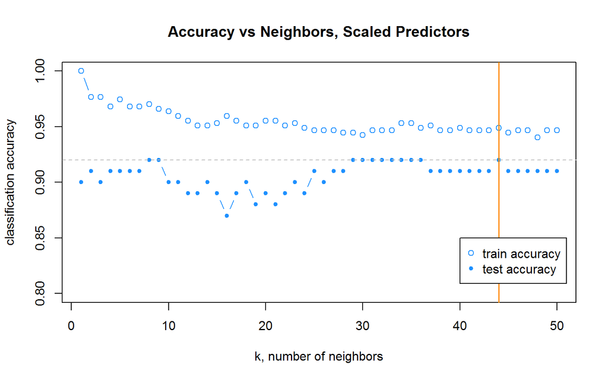

```r
# setup for unscaled results
set.seed(42)
k_to_try = 1:50
te_acc_k = rep(x = 0, times = length(k_to_try))
tr_acc_k = rep(x = 0, times = length(k_to_try))
```

```r
# train unscaled
for(i in seq_along(k_to_try)) {

  te_pred = knn(train = (X_wisc_train),
                test = (X_wisc_test),
                cl = y_wisc_train,
                k = k_to_try[i])

  tr_pred = knn(train = (X_wisc_train),
                test = (X_wisc_train),
                cl = y_wisc_train,
                k = k_to_try[i])

  te_acc_k[i] = accuracy(y_wisc_test, te_pred)
  tr_acc_k[i] = accuracy(y_wisc_train, tr_pred)

}
```

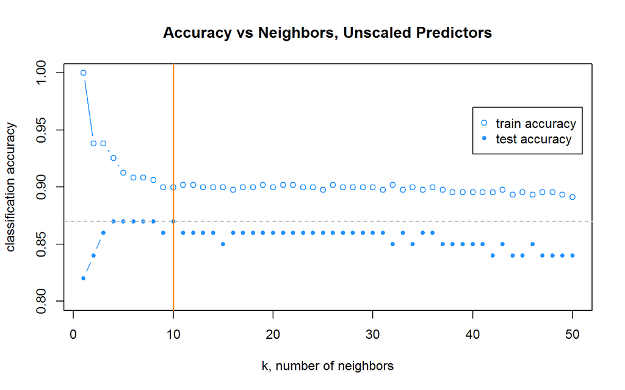

| Predictor Scaling | k | Test Accuracy |
| --- | --- | --- |
| Yes | 44 | 0.92 |
| No | 10 | 0.87 |

We see better performance with the predictor scaling.

# Exercise 2

**[15 points]** Calculate *train*, *test*, and *5-fold* *cross-validated* **accuracy** for both an **additive logistic regression** and **LDA**. You may use the `createFolds()` function from `caret`, but you may not use the `train()` function from `caret`.

Use your UIN in place of `uin`.

```r
uin = 123456789
set.seed(uin)
```

**Solution:**

```r
library(MASS)
```

```r
num_folds = 5
wisc_folds = caret::createFolds(wisc_train$class, k = num_folds)
```

```r
glm_acc = rep(0, times = num_folds)
lda_acc = rep(0, times = num_folds)
```

```r
for(i in seq_along(wisc_folds)) {

  # split for fold i
  train = wisc_train[-wisc_folds[[i]], ]
  valid = wisc_train[wisc_folds[[i]], ]

  # logistic regression
  glm_fit = glm(class ~ ., data = train, family = "binomial")
  glm_prob = predict(glm_fit, valid)
  glm_pred = ifelse(glm_prob > 0.5, "M", "B")
  glm_acc[i] = accuracy(actual = valid$class, predicted = glm_pred)

  # lda
  lda_fit = lda(class ~ ., data = train)
  lda_pred = predict(lda_fit, valid)$class
  lda_acc[i] = accuracy(actual = valid$class, predicted = lda_pred)

}
```

```r
# cv results
glm_cv = mean(glm_acc)
lda_cv = mean(lda_acc)
```

```r
# logistic
glm_fit = glm(class ~ ., data = wisc_train, family = "binomial")

# train acc
glm_train_prob = predict(glm_fit, wisc_train)
glm_train_pred = ifelse(glm_train_prob > 0.5, "M", "B")
glm_train_acc = accuracy(actual = wisc_train$class, predicted = glm_train_pred)

# test acc
glm_test_prob = predict(glm_fit, wisc_test)
glm_test_pred = ifelse(glm_test_prob > 0.5, "M", "B")
glm_test_acc = accuracy(actual = wisc_test$class, predicted = glm_test_pred)
```

```r
# lda
lda_fit = lda(class ~ ., data = wisc_train)

# train acc
lda_train_pred = predict(lda_fit, wisc_train)$class
lda_train_acc = accuracy(actual = wisc_train$class, predicted = lda_train_pred)

# test acc
lda_test_pred = predict(lda_fit, wisc_test)$class
lda_test_acc = accuracy(actual = wisc_test$class, predicted = lda_test_pred)
```

| Method | Train Accuracy | 5-Fold CV Accuracy | Test Accuracy |
| --- | --- | --- | --- |
| Logistic | 0.9594883 | 0.9466002 | 0.90 |
| LDA | 0.9402985 | 0.9381348 | 0.92 |